# Walmart - Store Sales Forecasting

newhyh

2021-06-12

### 캐글 대회 월마트 매출 데이터

https://www.kaggle.com/competitions/walmart-recruiting-store-sales-forecasting/overview

#### 분석 개요

##### 월마트의 각 상점 각 부서의 매출 데이터와 부가 정보(크기,cpi 등) 데이터를 이용하여 매출을 예측 test.csv에 결과변수가 없어, 결과 평가를 위해 분석에서는 전처리 된 train2를 다시 train과 test로 분리하여 진행함.

#### 캐글 대회 : 기간 종료 후 제출

[figure not shown]

**train.csv 변수 설명**  
store - 매장 번호  
dept - 부서 번호  
date - 날짜(주)  
IsHoliday - 해당 주가 특별한 휴일 주간인지 여부  
Weekly_Sales - 결과변수:해당 매장의 해당 부서에 대한 매출  
**features.csv 변수 설명**  
store - 매장 번호  
date - 날짜(주)  
Temperature - 해당 지역의 평균 기온  
Fuel_Price - 지역의 연료 비용  
MarkDown1-5 - Walmart가 실행 중인 판촉 인하와 관련된 익명 데이터입니다.  
CPI - 소비자 물가 지수  
Unemployment - 실업률  
sHoliday - 해당 주가 특별한 휴일 주간인지 여부  
**stores.csv 변수 설명**  
Store - 매장 번호  
Type - 상점의 형태  
Size - 상점의 크기  
**EDA 및 전처리**  
1) 상점/부서의 일자별 매출 데이터와 부가정보 데이터의 전처리 후 조인이 필요하다.  
2) 각 상점과 부서의 평균 매출, 부가 정보 변수에 따른 평균 매출 확인이 필요하다.  
**패키지**

```r
library(tidyverse)
library(car)
library(caret)
library(lubridate)
library(tidymodels)
library(GGally)
library(randomForest)
library(doParallel)
```

#### train.csv, test.csv =======================================================

**데이터 불러오기**

```r
file_path <- "./data/"
train <- read_csv(file.path(file_path,"train.csv" )) %>% as.data.frame()
```

**변수명 처리**

```r
train <- train %>%  janitor::clean_names()
```

### EDA 탐색적 데이터 분석

```r
train %>% str()
```

```
## 'data.frame':    421570 obs. of  5 variables:
##  $ store       : num  1 1 1 1 1 1 1 1 1 1 ...
##  $ dept        : num  1 1 1 1 1 1 1 1 1 1 ...
##  $ date        : Date, format: "2010-02-05" "2010-02-12" ...
##  $ weekly_sales: num  24925 46039 41596 19404 21828 ...
##  $ is_holiday  : logi  FALSE TRUE FALSE FALSE FALSE FALSE ...
```

5개 변수 421570개 케이스 대량 데이터이다.  
**결측치 확인**

```r
train %>% is.na() %>% colSums()
```

```
##        store         dept         date weekly_sales   is_holiday
##            0            0            0            0            0
```

```r
train %>% summary()
```

```
##      store           dept            date             weekly_sales
##  Min.   : 1.0   Min.   : 1.00   Min.   :2010-02-05   Min.   : -4989
##  1st Qu.:11.0   1st Qu.:18.00   1st Qu.:2010-10-08   1st Qu.:  2080
##  Median :22.0   Median :37.00   Median :2011-06-17   Median :  7612
##  Mean   :22.2   Mean   :44.26   Mean   :2011-06-18   Mean   : 15981
##  3rd Qu.:33.0   3rd Qu.:74.00   3rd Qu.:2012-02-24   3rd Qu.: 20206
##  Max.   :45.0   Max.   :99.00   Max.   :2012-10-26   Max.   :693099
##  is_holiday
##  Mode :logical
##  FALSE:391909
##  TRUE :29661
##
##
##
```

**결과변수 히스토그램**

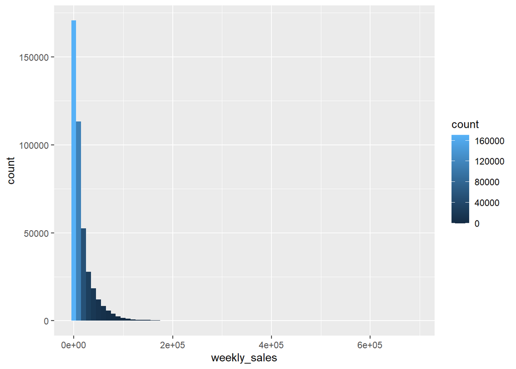

```r
train %>%
  ggplot(aes(x =weekly_sales)) +
  geom_histogram(aes(fill=..count..),binwidth=10000  )
```

심각한 오른쪽 꼬리 분포이다. 박스콕스 변환 고려

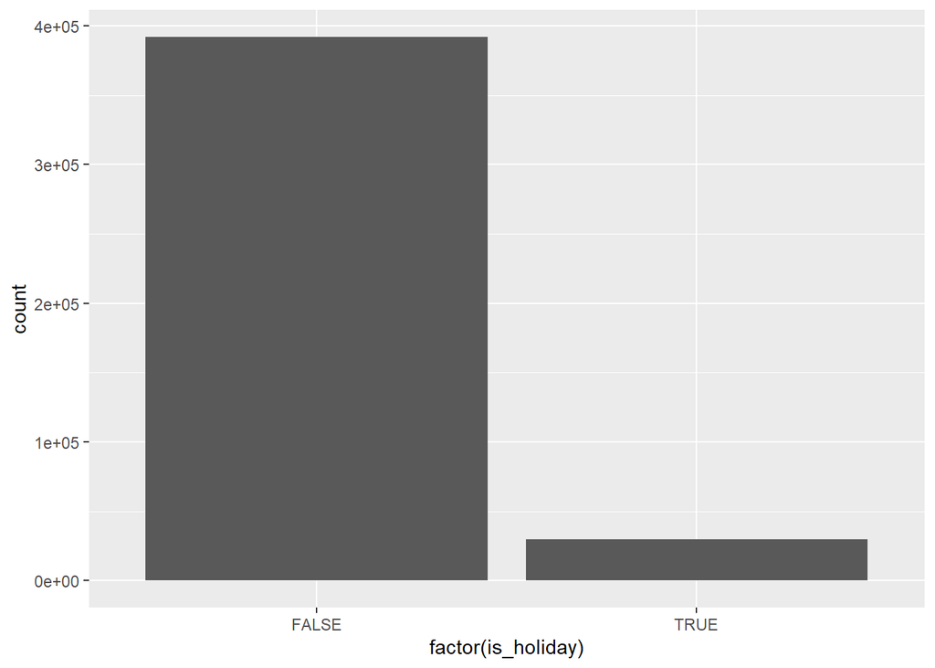

```r
train %>% ggplot(aes(factor(is_holiday))) + geom_bar()
```

**월/주/일 분리 & 형변환**

```r
train <- train %>%
  mutate(year = year(date),
         month = as.integer(month(date)),
         day = as.integer(day(date)),
         store= as.integer(store),
         dept= as.integer(dept),
         is_holiday = factor(is_holiday)
         )
```

```r
train %>% str()
```

```
## 'data.frame':    421570 obs. of  8 variables:
##  $ store       : int  1 1 1 1 1 1 1 1 1 1 ...
##  $ dept        : int  1 1 1 1 1 1 1 1 1 1 ...
##  $ date        : Date, format: "2010-02-05" "2010-02-12" ...
##  $ weekly_sales: num  24925 46039 41596 19404 21828 ...
##  $ is_holiday  : Factor w/ 2 levels "FALSE","TRUE": 1 2 1 1 1 1 1 1 1 1 ...
##  $ year        : num  2010 2010 2010 2010 2010 2010 2010 2010 2010 2010 ...
##  $ month       : int  2 2 2 2 3 3 3 3 4 4 ...
##  $ day         : int  5 12 19 26 5 12 19 26 2 9 ...
```

**매장(store) 수와 부서(dept) 수 확인**

```r
train$store %>% unique()%>% length()
```

```
## [1] 45
```

```r
train$dept %>% unique()%>% length()
```

```
## [1] 81
```

```r
# 매장 45개 부서 81개
```

```r
train <- train %>% mutate(store_dept = paste0(store,"_",dept) )
train$store_dept <- factor(train$store_dept)
```

**휴일여부별 매장별 부서별 weekly_sales boxplot 확인**

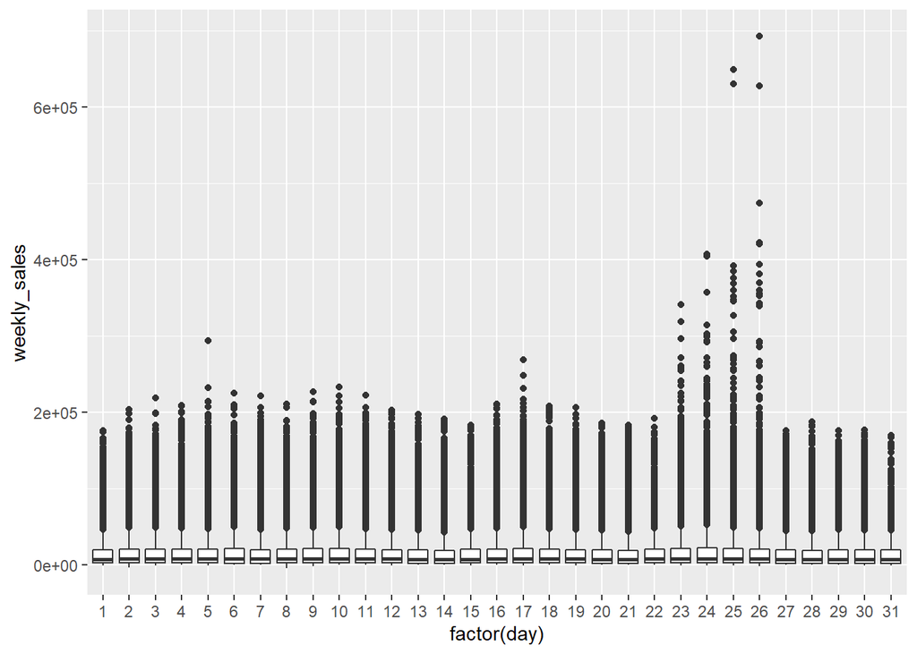

```r
train %>%
  ggplot(aes(x=factor(day),y = weekly_sales )) +
  geom_boxplot()
```

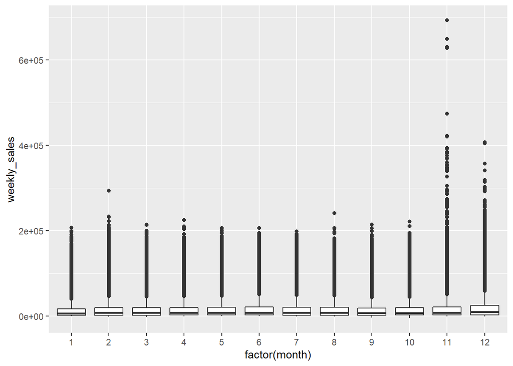

```r
train %>%
  ggplot(aes(x=factor(month),y = weekly_sales )) +
  geom_boxplot()
```

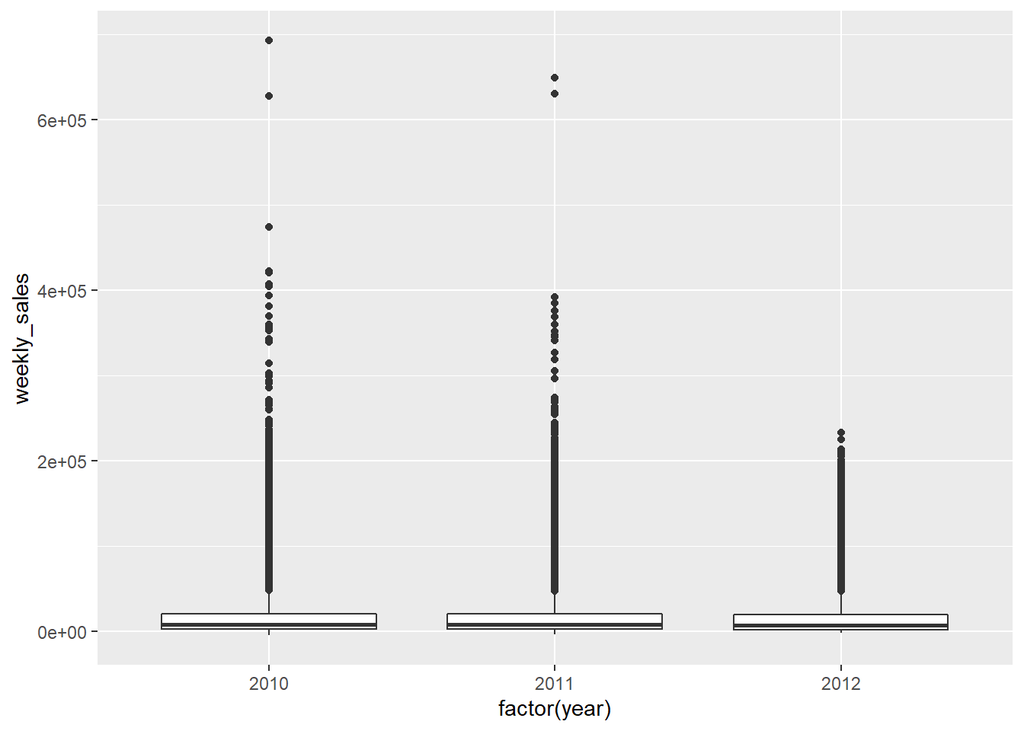

```r
train %>%
  ggplot(aes(x=factor(year),y = weekly_sales )) +
  geom_boxplot()
```

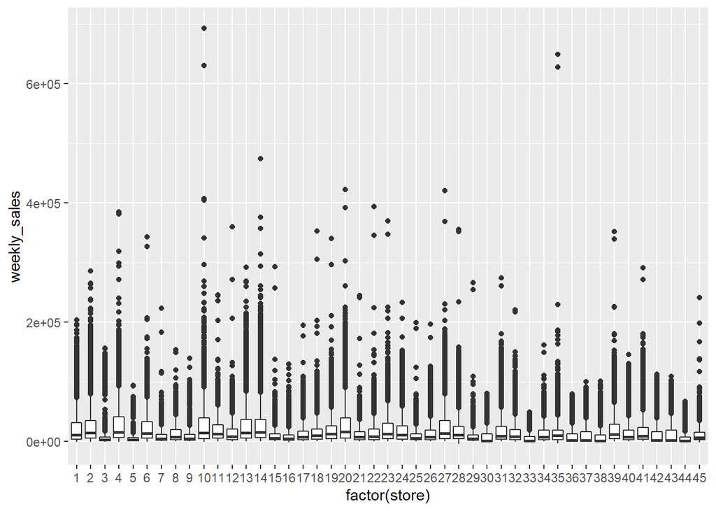

```r
train %>%
  ggplot(aes(x=factor(store),y = weekly_sales )) +
  geom_boxplot()
```

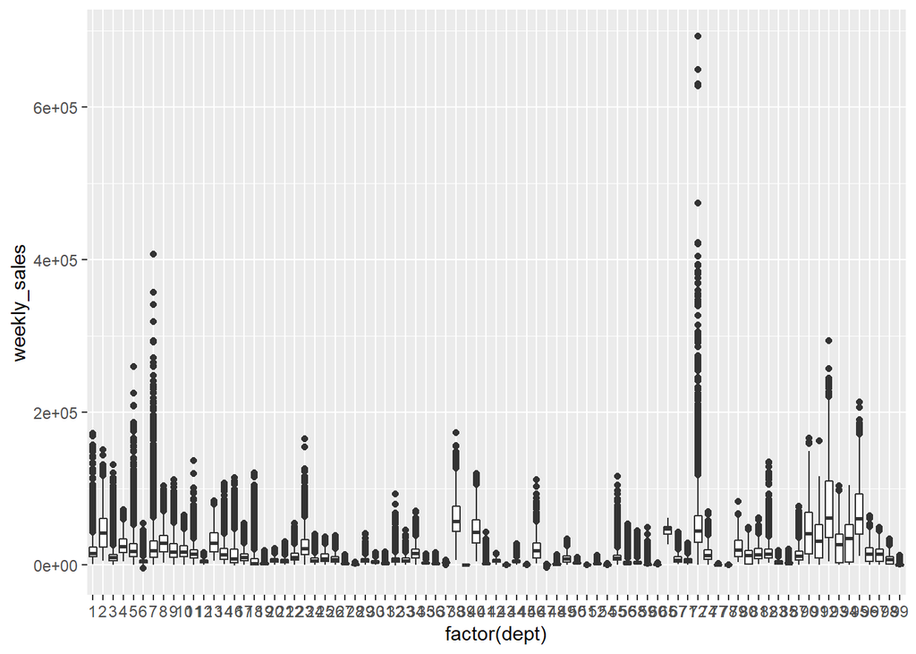

```r
train %>%
  ggplot(aes(x=factor(dept),y = weekly_sales )) +
  geom_boxplot()
```

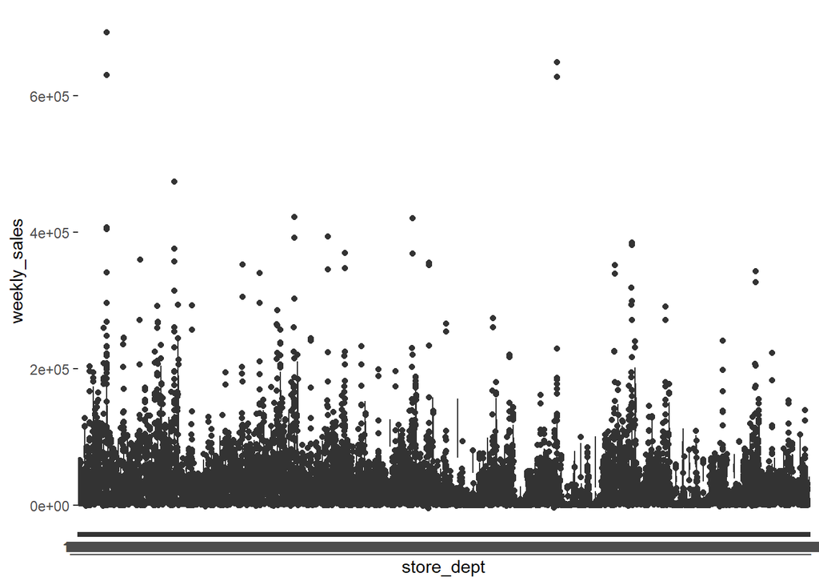

```r
train %>%
  ggplot(aes(x=store_dept,y = weekly_sales )) +
  geom_boxplot()
```

날짜 변수보다 store, dept의 의한 4분위수 변동폭이 훨씬 더 크다.

**연도별 월 평균 매출**

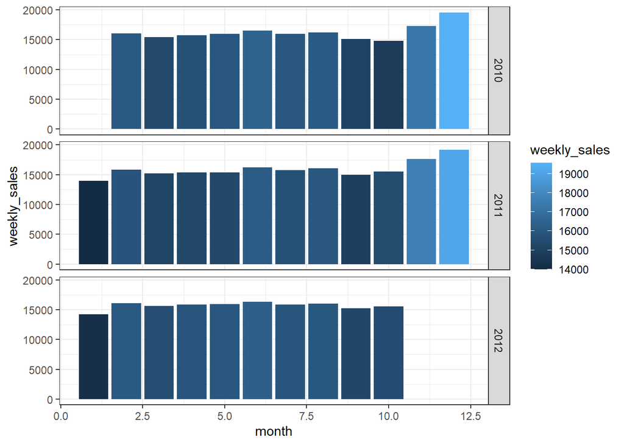

```r
agg <- aggregate(weekly_sales~year+month,train,'mean')
colnames(agg) <- c("year","month","weekly_sales")
ggplot(data=agg, aes(x=month, y=weekly_sales,fill=weekly_sales))+
  geom_bar(stat = "identity") + facet_grid(year~.)+theme_bw()
```

연도에 따라 매출이 없는 ’월’이 존재한다.  
**월,일,휴무일에 따른 매출 평균**

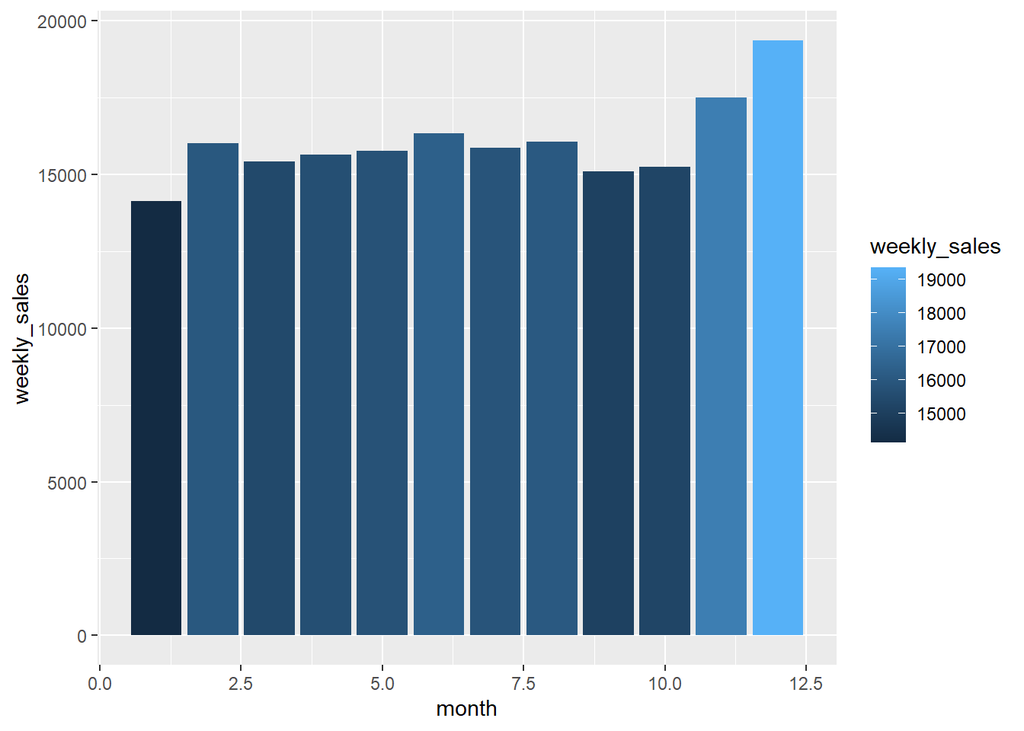

```r
datem_1 <- train %>% group_by(month) %>% summarise(mean(weekly_sales))
colnames(datem_1)[2] <- "weekly_sales"
ggplot(datem_1, aes(month,weekly_sales,fill=weekly_sales)) +geom_bar(stat = "identity")
```

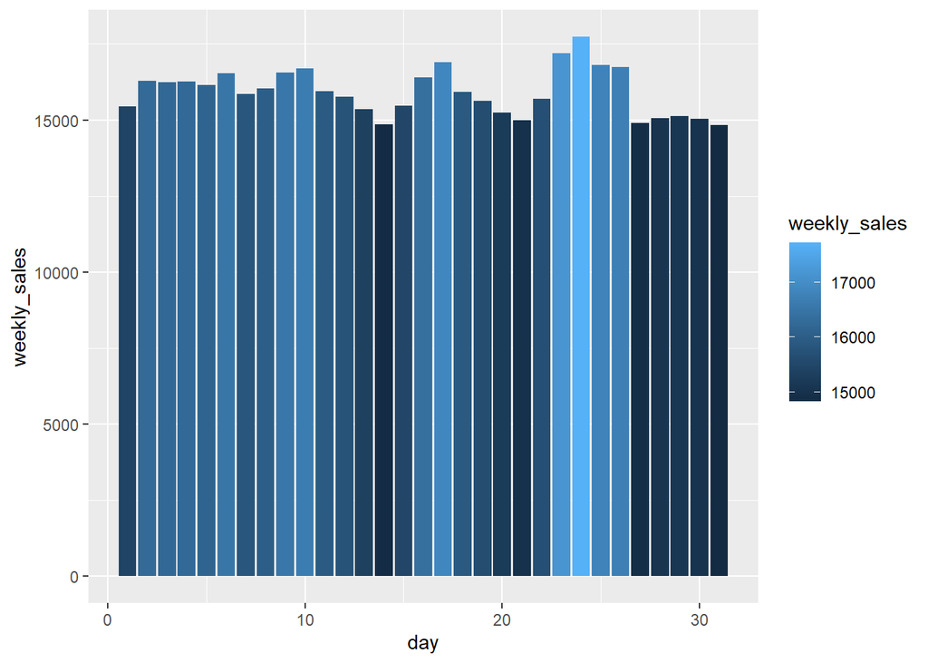

```r
datem_2 <- train %>% group_by(day) %>% summarise(mean(weekly_sales))
colnames(datem_2)[2] <- "weekly_sales"
ggplot(datem_2, aes(day,weekly_sales,fill=weekly_sales)) +geom_bar(stat = "identity")
```

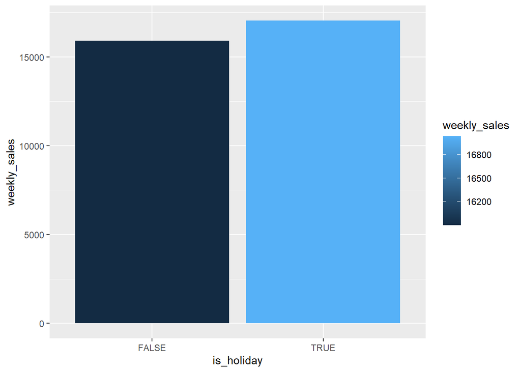

```r
datem_h <- train %>% group_by(is_holiday) %>% summarise(mean(weekly_sales))
colnames(datem_h)[2] <- "weekly_sales"
ggplot(datem_h, aes(is_holiday,weekly_sales,fill=weekly_sales)) +geom_bar(stat = "identity")
```

**store, dept별 매출 평균**

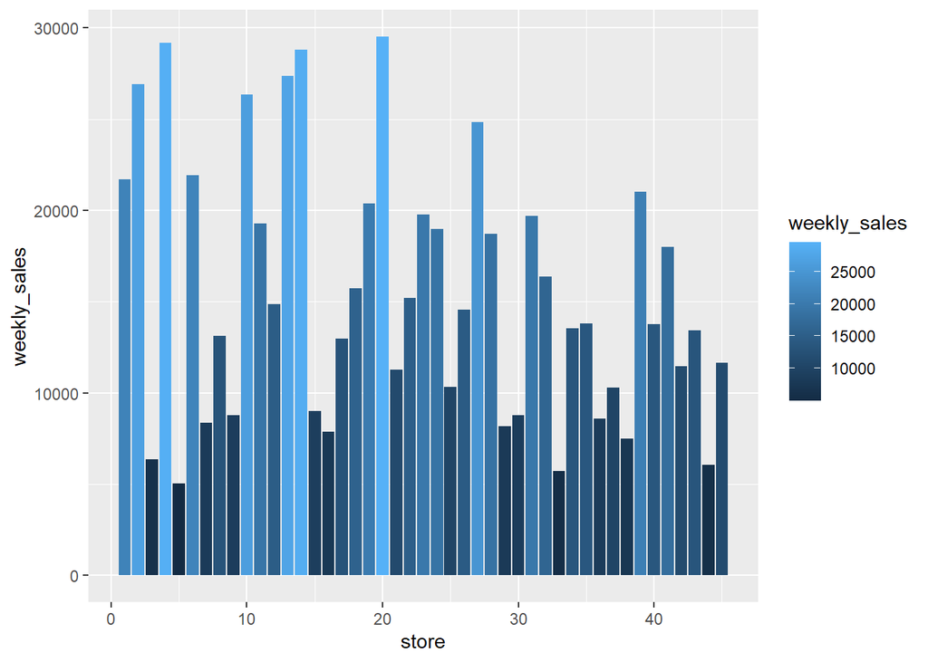

```r
datem_3 <- train %>% group_by(store) %>% summarise(mean(weekly_sales))
colnames(datem_3)[2] <- "weekly_sales"
ggplot(datem_3, aes(store,weekly_sales,fill=weekly_sales)) +geom_bar(stat = "identity")
```

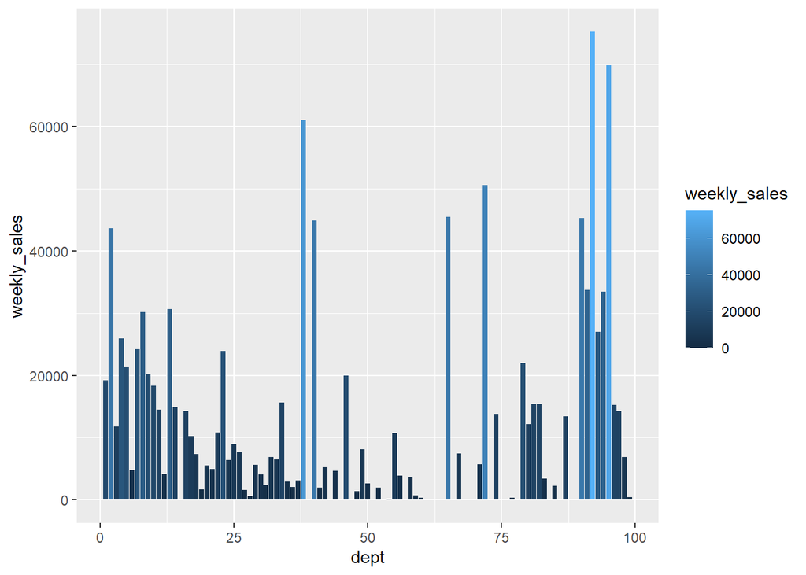

```r
datem_4 <- train %>% group_by(dept) %>% summarise(mean(weekly_sales))
colnames(datem_4)[2] <- "weekly_sales"
ggplot(datem_4, aes(dept,weekly_sales,fill=weekly_sales)) +geom_bar(stat = "identity")
```

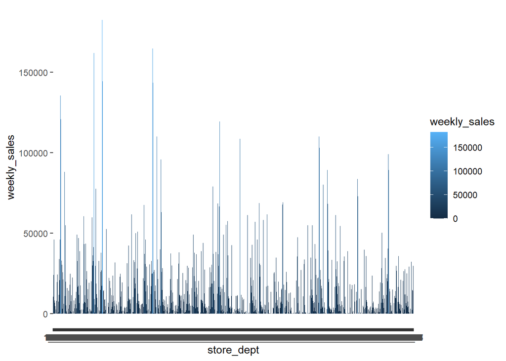

```r
datem_5 <- train %>% group_by(store_dept) %>% summarise(mean(weekly_sales))
colnames(datem_5)[2] <- "weekly_sales"
ggplot(datem_5, aes(store_dept,weekly_sales,fill=weekly_sales)) +geom_bar(stat = "identity")
```

년/월 별로 구해진 평균 매출 차이보다 store/dept별로 구해진 평균 매출 차이가 훨씬 크게 난다.

#### features.csv, stores.csv ==================================================

```r
file_path <- "./data/"
features <- read_csv(file.path(file_path,"features.csv" )) %>% as.data.frame()
stores <- read_csv(file.path(file_path,"stores.csv" )) %>% as.data.frame()
```

```r
features %>% str()
# 12변수 8190
stores %>% str()
# 3변수  45
```

**결측치 확인**

```r
features %>% is.na() %>% colSums()
stores %>% is.na() %>% colSums()
```

```r
nrow(features)/2
features %>% summary()
stores %>% summary()
```

[output not shown]

train 날짜 Min. :2010-02-05 Max. :2012-10-26

features 날짜 Min. :2010-02-05 Max. :2013-07-26

**features 2012-10-26 이후 날짜 삭제**

```r
features0 <- features
features %>% dim()
```

```
## [1] 8190   12
```

```r
features <- features[features$Date <= as.Date("2012-10-26"),]
features %>% dim()
```

```
## [1] 6435   12
```

```r
features %>% is.na() %>% colSums()
```

[output not shown]

**결측치가 50%이상인 변수 삭제**

```r
features <- features %>% select(-c(MarkDown1,MarkDown2,MarkDown3,MarkDown4,MarkDown5))
```

**features.csv, stores.csv 데이터 합치기 : features_stores**

```r
features_stores <- left_join(features,stores,by='Store')
features_stores <- features_stores %>%  janitor::clean_names()
features_stores %>% is.na() %>% colSums()
```

**features_stores 요약보기**

```r
features_stores1_1 <- features_stores
features_stores1_1 %>% summary()
```

```
##      store         date             temperature       fuel_price
##  Min.   : 1   Min.   :2010-02-05   Min.   : -2.06   Min.   :2.472
##  1st Qu.:12   1st Qu.:2010-10-08   1st Qu.: 47.46   1st Qu.:2.933
##  Median :23   Median :2011-06-17   Median : 62.67   Median :3.445
##  Mean   :23   Mean   :2011-06-17   Mean   : 60.66   Mean   :3.359
##  3rd Qu.:34   3rd Qu.:2012-02-24   3rd Qu.: 74.94   3rd Qu.:3.735
##  Max.   :45   Max.   :2012-10-26   Max.   :100.14   Max.   :4.468
##       cpi         unemployment    is_holiday          type
##  Min.   :126.1   Min.   : 3.879   Mode :logical   Length:6435
##  1st Qu.:131.7   1st Qu.: 6.891   FALSE:5985      Class :character
##  Median :182.6   Median : 7.874   TRUE :450       Mode  :character
##  Mean   :171.6   Mean   : 7.999
##  3rd Qu.:212.7   3rd Qu.: 8.622
##  Max.   :227.2   Max.   :14.313
##       size
##  Min.   : 34875
##  1st Qu.: 70713
##  Median :126512
##  Mean   :130288
##  3rd Qu.:202307
##  Max.   :219622
```

```r
features_stores1_1 %>% str()
```

```
## 'data.frame':    6435 obs. of  9 variables:
##  $ store       : num  1 1 1 1 1 1 1 1 1 1 ...
##  $ date        : Date, format: "2010-02-05" "2010-02-12" ...
##  $ temperature : num  42.3 38.5 39.9 46.6 46.5 ...
##  $ fuel_price  : num  2.57 2.55 2.51 2.56 2.62 ...
##  $ cpi         : num  211 211 211 211 211 ...
##  $ unemployment: num  8.11 8.11 8.11 8.11 8.11 ...
##  $ is_holiday  : logi  FALSE TRUE FALSE FALSE FALSE FALSE ...
##  $ type        : chr  "A" "A" "A" "A" ...
##  $ size        : num  151315 151315 151315 151315 151315 ...
```

```r
features_stores1_1$store %>% unique() %>% length()
```

```
## [1] 45
```

```r
features_stores1_1$type %>% unique() %>% length()
```

```
## [1] 3
```

```r
features_stores1_1$size %>% unique() %>% length()
```

```
## [1] 40
```

```r
features_stores1_1$type <- factor(features_stores1_1$type)
```

**features_stores1_1 히스토그램 확인**

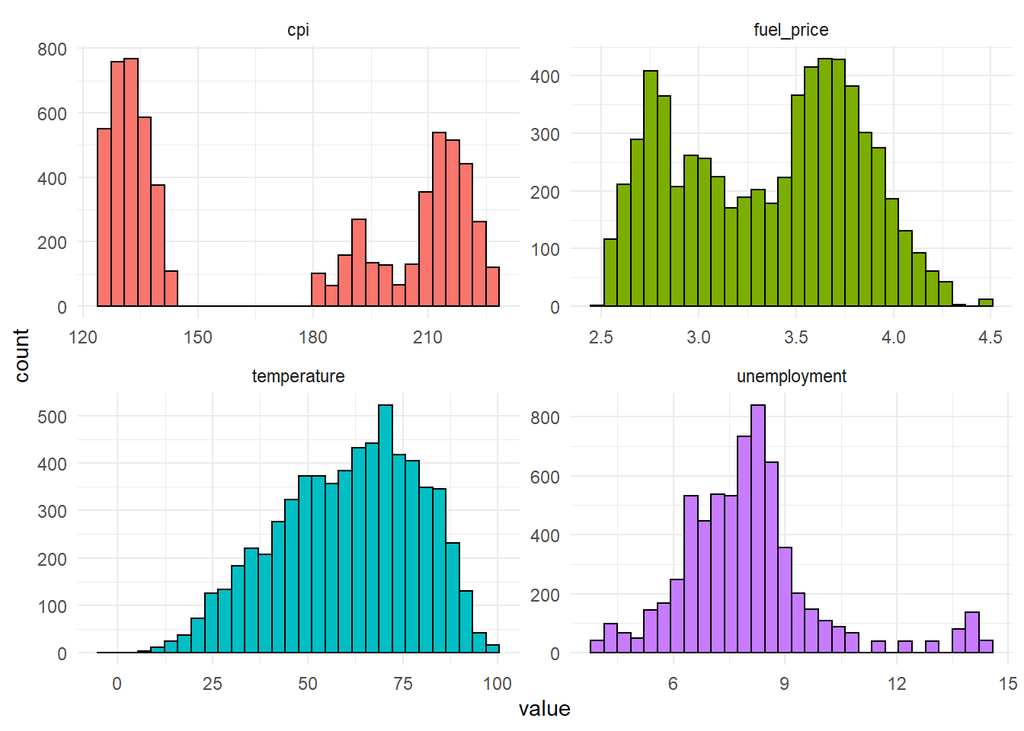

```r
 features_stores1_1 %>% select(-c(store,size)) %>% select_if(is.numeric) %>%
  gather() %>%
  ggplot() +
  geom_histogram(mapping = aes(x=value,fill=key), color="black") +
  facet_wrap(~ key, scales = "free") +
  theme_minimal() +
  theme(legend.position = 'none')
```

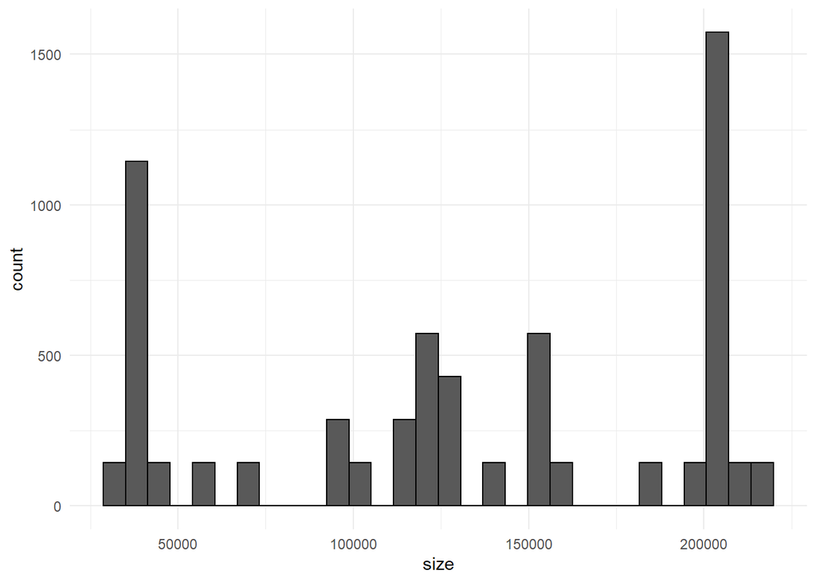

```r
features_stores1_1 %>%
  ggplot() +
  geom_histogram(mapping = aes(x=size,fill=size), color="black")+
    theme_minimal() +
  theme(legend.position = 'none')
```

### 전처리

**train & features_stores 조인하기 : store & date 기준**  
**공통변수로 사용할 ‘store & date’ 변수 만들기**

```r
train <- mutate(train,store_date = paste0(store,"-",date))

features_stores_s <- mutate(features_stores1_1, store_date=paste0(store,"-",date))
```

**features_stores 최종 변수 선택**

```r
features_stores3 <- features_stores_s %>%  select(store_date,temperature,fuel_price,cpi,unemployment,type,size)
```

**조인하기**

```r
train_1 <- left_join(train,features_stores3,by='store_date')
train_1 <- train_1 %>% select(-c(store_date,date))
str(train_1)
train_1 %>% is.na() %>% colSums()
```

#### **그룹별 평균으로 예측 변수 만들기**

**그룹별 평균**  
store,dept를 기준으로 month,day,is_holiday,size별 매출 평균 변수들을 생성한다.

```r
group_sales1 <- train_1 %>% group_by(store,dept,month) %>% summarise(mean(weekly_sales))
group_sales3 <- train_1 %>% group_by(store,dept,day) %>% summarise(mean(weekly_sales))
group_sales4 <- train_1 %>% group_by(store,dept,is_holiday) %>% summarise(mean(weekly_sales))
```

```r
train_1$size <- train_1$size %>% cut(20,labels=c(1:20)) %>% as.integer
train_a <- train_1
```

```r
group_sales5 <- train_1 %>% group_by(store,dept,size) %>% summarise(mean(weekly_sales))
group_sales5 %>% is.na() %>% colSums()
```

```
##              store               dept               size mean(weekly_sales)
##                  0                  0                  0                  0
```

**그룹별 평균 변수 이름 변경**

```r
colnames(group_sales1)[4] <- "mean_storedept_month"
colnames(group_sales3)[4] <- "mean_storedept_day"
colnames(group_sales4)[4] <- "mean_storedept_is_holiday"
colnames(group_sales5)[4] <- "mean_storedept_is_size"
```

**train_1과 조인하기**

```r
train_1_1 <- left_join(train_a,group_sales1,by=c(
  'store'='store','dept'='dept', 'month'='month'))
train_1_3 <- left_join(train_1_1,group_sales3,by=c(
  'store'='store','dept'='dept', 'day'='day'))
train_1_4 <- left_join(train_1_3,group_sales4,by=c(
  'store'='store','dept'='dept', 'is_holiday'='is_holiday'))
train_1_5 <- left_join(train_1_4,group_sales5,by=c(
  'store'='store','dept'='dept', 'size'='size'))
```

```r
train_1_5 %>% str()
```

**변수 간 상관계수 확인**

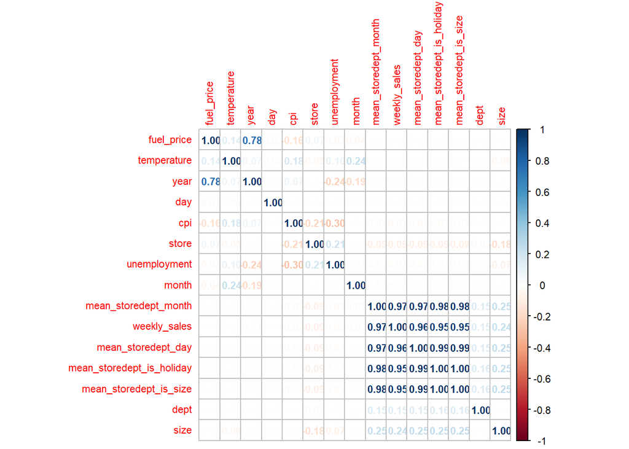

```r
library(corrplot)
cod <- train_1_5 %>% select_if(is.numeric) %>% cor()
corrplot(cod,method="number", order="AOE",tl.cex=0.7,cl.cex=0.7,number.cex=0.7 )
```

```r
train_1_6 <- train_1_5 %>% select(weekly_sales,is_holiday,year,month,day,fuel_price,cpi,unemployment,mean_storedept_month,mean_storedept_day,mean_storedept_is_holiday,mean_storedept_is_size )
```

### 분석

**본 분석을 위한 데이터 분할 : train_1_6를 다시 train과 test로 분리하여 진행함.**

```r
set.seed(1234)
splits <- train_1_6 %>% initial_split(prop = 0.7, strata = weekly_sales)
train2r <- training(splits)
test2r <- testing(splits)
```

```r
train2r %>% is.na() %>% colSums()
```

#### 레시피

```r
rec <- train2r %>%
  recipe(weekly_sales ~ .) %>%
  step_BoxCox(all_numeric_predictors()) %>%
  step_normalize(all_numeric_predictors()) # %>%  step_dummy(all_nominal())
```

bake **데이터 분할**

```r
pre <- prep(rec)
train2 <- bake(pre, new_data=NULL)
test2 <- bake(pre, new_data=test2r)
```

**train2 결과변수 정규분포화 : 박스콕스 변환**

```r
# 박스콕스 변환 필요성 여부
train2<-train2[-which(train2$weekly_sales<=0),] # 0 이하 데이터 삭제
summary(powerTransform(train2$weekly_sales))
```

```
## bcPower Transformation to Normality
##                     Est Power Rounded Pwr Wald Lwr Bnd Wald Upr Bnd
## train2$weekly_sales    0.2136        0.21        0.212       0.2153
##
## Likelihood ratio test that transformation parameter is equal to 0
##  (log transformation)
##                            LRT df       pval
## LR test, lambda = (0) 76493.64  1 < 2.22e-16
##
## Likelihood ratio test that no transformation is needed
##                          LRT df       pval
## LR test, lambda = (1) 542300  1 < 2.22e-16
```

```r
p1 <- powerTransform(train2$weekly_sales)
train2$weekly_sales <- train2$weekly_sales^p1$lambda
train2$weekly_sales %>% head()
```

```
## [1] 4.6831045 4.8678653 4.6074054 3.9002813 0.6667806 1.9539565
```

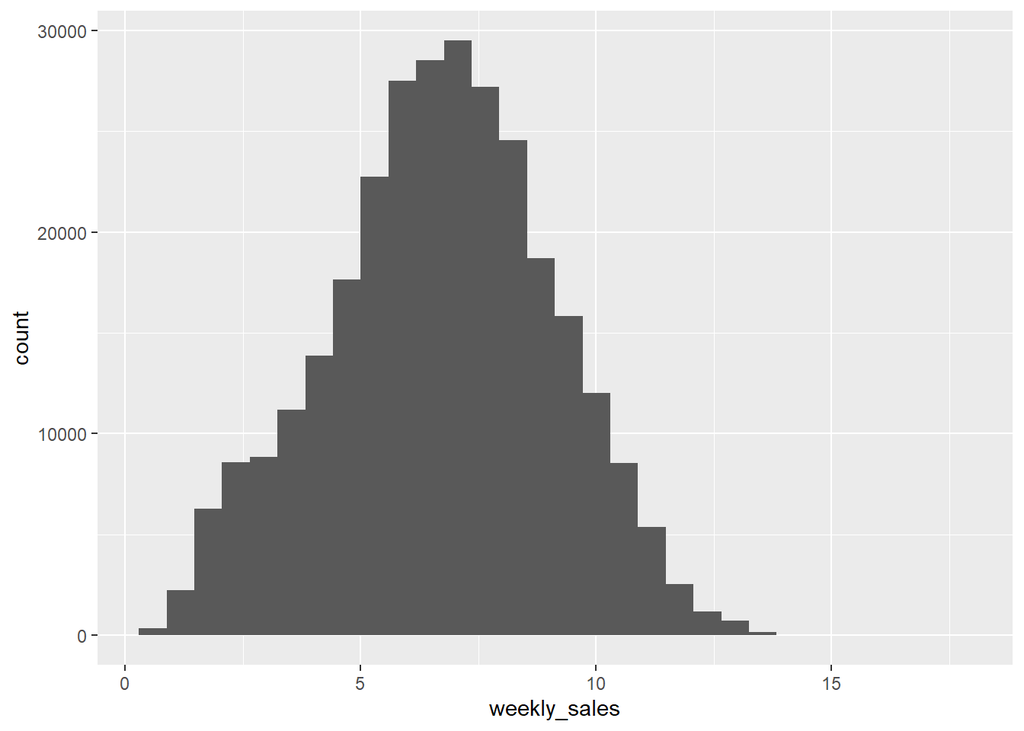

```r
train2 %>%  ggplot(aes(x = weekly_sales)) + geom_histogram()
```

```r
file_path <- "./data/"
#save.image(file=paste0(file_path, "walmart_upload.RData" ))
load(paste0(file_path, "walmart_upload.RData" ))
```

**랜덤포레스트 : 30만개의 대량의 데이터여서 PC의 성능 한계로 조율 모수 학습은 생략하고 기본 랜덤포레스트로 분석**

```r
rf.model<-randomForest(weekly_sales ~.,
                       data=train2,
                       ntree=10,
                       mtry=5,
                       importance=T)
```

**예측**

```r
rf.pred_0 <- predict(rf.model,test2 )
rf.pred_0 %>% head()
```

```
##        1        2        3        4        5        6
## 9.132991 9.553658 9.183207 8.467136 9.922844 8.042210
```

**박스콕스 이전 데이터로 복원**

```r
rf.pred_1 <- rf.pred_0^(1/p1$lambda)
rf.pred_1 %>% head()
```

```
##        1        2        3        4        5        6
## 30681.52 37863.70 31477.46 21543.48 45199.68 16938.31
```

**평가**

```r
postResample(pred = rf.pred_1 , obs = test2$weekly_sales )
```

```
##         RMSE     Rsquared          MAE
## 2.679697e+04 6.474865e-01 1.553718e+04
```